# (PSL) Coding Assignment 1

Fall 2021

## Data Generation

This assignment is related to the simulation study described in Section 2.3.1 (the so-called Scenario 2) of “Elements of Statistical Learning” (ESL).

**Scenario 2**: the two-dimensional data $X \in R^2$ in each class is generated from a mixture of 10 different bivariate Gaussian distributions with uncorrelated components and different means, i.e.,
$$X \ | \ Y = k, Z = j \quad \sim \mathcal{N}(\mathbf{m}_{kj}, s^2 I_2)$$

where $k = 0$ or $1$, and $j=1, 2, \dots, 10$. Set
$$P(Y=k) = 1/2, \quad P(Z=j) = 1/10, \quad s^2 = 1/5.$$
In other words, given $Y=k$, $X$ follows a mixture distribution with density function

$$\frac{1}{10} \sum_{j=1}^{10} \left ( \frac{1}{\sqrt{2 \pi s^2}} \right )^2 e^{ -\|\mathbf{x} - \mathbf{m}_{kj} \|^2/(2 s^2)}.$$

#### Generate Centers

Generate the 10 centers associated with class 1 from one normal distribution and the 10 centers associated with class 0 from another normal distribution as follows:
$$\mathbf{m}_{1j} \sim \mathcal{N} \Big ( \left ( \begin{array}{c} 1 \\ 0 \end{array} \right ), \mathbf{I}_2 \Big ), \quad \mathbf{m}_{0j} \sim \mathcal{N} \Big ( \left ( \begin{array}{c} 0 \\ 1 \end{array} \right ), \mathbf{I}_2 \Big ).$$

```r
p = 2;
csize = 10;     # number of centers
sigma = 1;      # sd for generating the centers
m1 = matrix(rnorm(csize*p), csize, p)*sigma +
  cbind( rep(1, csize), rep(0, csize))
m0 = matrix(rnorm(csize*p), csize, p)*sigma +
  cbind( rep(0, csize), rep(1, csize))
```

#### Generate Data

Following the data generating process described above, write a function `datagen` to return a training sample of size 200 and a test sample of size 10,000 given generated centers.

```r
sim_params = list(
 csize = 10,      # number of centers
 p = 2,           # dimension
 s = sqrt(1/5),   # standard deviation for generating data
 n = 100,         # training size per class
 N = 5000,        # test size per class
 m0 = m0,         # 10 centers for class 0
 m1 = m1         # 10 centers for class 1
)
generate_sim_data = function(sim_params){
  p = sim_params$p
  s = sim_params$s
  n = sim_params$n
  N = sim_params$N
  m1 = sim_params$m1
  m0 = sim_params$m0
  csize = sim_params$csize

  id1 = sample(1:csize, n, replace = TRUE);
  id0 = sample(1:csize, n, replace = TRUE);
  traindata = matrix(rnorm(2*n*p), 2*n, p)*s + rbind(m1[id1,], m0[id0,])
  Ytrain = factor(c(rep(1,n), rep(0,n)))
  shuffle_row_id = sample(1:n)
  id1 = sample(1:csize, N, replace=TRUE);
  id0 = sample(1:csize, N, replace=TRUE);
  testdata = matrix(rnorm(2*N*p), 2*N, p)*s + rbind(m1[id1,], m0[id0,])
  Ytest = factor(c(rep(1,N), rep(0,N)))

  # Return the training/test data along with labels
  list(
  traindata = traindata,
  Ytrain = Ytrain,
  testdata = testdata,
  Ytest = Ytest
  )
}
```

#### Visulize the Data

```r
mydata = generate_sim_data(sim_params)
traindata = mydata$train
Ytrain = mydata$Ytrain
testdata = mydata$testdata
Ytest = mydata$Ytest
mycol = rep("blue", nrow(traindata))
mycol[Ytrain==0] = "red"
plot(traindata[, 1], traindata[, 2], type = "n", xlab = "", ylab = "")
points(traindata[, 1], traindata[, 2], col = mycol);
```

```r
points(m1[, 1], m1[, 2], pch = "+", cex = 2, col = "blue");
points(m0[, 1], m0[, 2], pch = "+", cex = 2, col = "red");
```

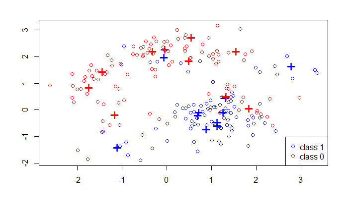

```r
legend("bottomright", pch = c(1,1), col = c("blue", "red"),
       legend = c("class 1", "class 0"))
```

## Part I

In the first part of this assignment, you are asked to:

1. Write your own KNN code without using any packages;
2. Explain how you handle distance ties and voting ties;
3. Test your code with `mydata` when K = 1, 3, 5; compare your results with the ones from the R command `knn`.

**distance ties** may occur when you have multiple (training) observations that are equidistant from a test observation.

**voting ties** may occur when K is an even number and you have 50% of the k-nearest-neighhors from each of the two classes.

Display your result on `testdata` as the following 2-by-2 table for K = 1, 3, 5 and they should match with the results from `knn`. **Note** that your result will not look the same as the one shown below since the data are different.

```r
myKNN = function(traindata, testdata, k){
  #initialize prediction vector with -1s

  pred_vec = rep(-1, nrow(testdata))
  for (i in 1:nrow(testdata)){
    temp = matrix(testdata[i,], nrow = nrow(traindata), ncol = ncol(traindata), byrow = TRUE)
    temp = (traindata - temp)^2
    temp = rowSums(temp)
    temp = sqrt(temp)
    temp = cbind(dist = temp, label = Ytrain) #temp matrix nx2 contains distance and label
    temp = temp[order(temp[,1], decreasing = FALSE),]
    #print(temp)
    label_1 = 0
    label_2 = 0
    majority = NULL
    for (index in 1:k){
      label = temp[index, 2]
      #label 2 is really label 1 due to R's convention
      if (label == 2){
        label_2 = label_2 + 1
      }
      #all labels are either 1 or 2
      else{
        label_1 = label_1 + 1
      }
    }
    #case 1: see if there is a tie
    if (label_1 == label_2){
      kth_neighbor = temp[k,2]
      majority = ifelse(kth_neighbor == 2, 1, 2)
    }
    #case2: no tie
    else{
    majority = ifelse (label_1 > label_2, 1, 2)
    pred_vec[i] = majority
    }
  }
  pred_vec
}
```

```r
pred_vec_k1 = myKNN(traindata = traindata, testdata = testdata, k = 1)
pred_vec_k3 = myKNN(traindata = traindata, testdata = testdata, k = 3)
pred_vec_k5 = myKNN(traindata = traindata, testdata = testdata, k = 5)
```

```r
sum(pred_vec_k1 > 1) #count classified as label 2
```

```
[1] 5212
```

```r
sum(pred_vec_k1 < 2) #count classified as label 1
```

```
[1] 4788
```

```r
library(class)
test.pred = knn(traindata, testdata, Ytrain, k = 1)
table(Ytest, test.pred)
```

```
     test.pred
Ytest    0    1
    0 3690 1310
    1 1098 3902
```

```r
test.pred = knn(traindata, testdata, Ytrain, k = 3)
table(Ytest, test.pred)
```

```
     test.pred
Ytest    0    1
    0 3935 1065
    1  919 4081
```

```r
test.pred = knn(traindata, testdata, Ytrain, k = 5)
table(Ytest, test.pred)
```

```
     test.pred
Ytest    0    1
    0 4147  853
    1  966 4034
```

## Part II

In the second part of this assignment, you are asked to use the **same** set of centers `m1` and `m0`, and repeat the data generating process using `generate_sim_data` 50 times. For each dataset, calculate the training and test errors (the averaged 0/1 error) for each the following four procedures:

1. Linear regression with cut-off value 0.5,
2. quadratic regression with cut-off value 0.5,
3. KNN classification with K chosen by 10-fold cross-validation, and
4. the Bayes rule (assume your know the values of 20 centers and s).

> Summarize your results on training errors and test errors graphically, e.g., using boxplot or stripchart. Also report the mean and standard error for the chosen K values.

**Note**:

- For KNN, you can use the function `knn` from R package `class`, instead of your own KNN function from Part I.
- “report the mean and standard error for the chosen K values” – For each data set, you have a K value chosen via 10-fold CV. Report the mean and standard error of the 50 K values.

### Regression

Fit a linear/quadratic regression model on the training data and use cut-off value $.5$ to transform numerical outcomes to binary outcomes. For illustration purpose, let’s try quadratic regression on one pair of training/test sets.

```r
fit_lin_model = function(sim_data, verbose = FALSE){
  # change Y from factor to numeric
  sim_data$Ytrain = as.numeric(sim_data$Ytrain) - 1
  sim_data$Ytest = as.numeric(sim_data$Ytest) - 1

  # fit a quadratic regression model
  model = lm(
    sim_data$Ytrain ~ .,
    as.data.frame(sim_data$traindata)
  )
  if (verbose) {
    print(summary(model))
  }

  decision_thresh = 0.5
  train_pred = as.numeric(model$fitted.values > decision_thresh)

  test_yhat = predict(
    model,
    newdata=as.data.frame(sim_data$testdata)
  )
  test_pred = as.numeric(test_yhat > decision_thresh)

  # return the mean classification errors on training/test sets
  list(
    train_error = sum(sim_data$Ytrain  != train_pred) / length(sim_data$Ytrain),
    test_error = sum(sim_data$Ytest  != test_pred) /
      length(sim_data$Ytest)
  )
}
```

```r
lin_model = fit_lin_model(mydata, verbose = TRUE)
```

```
Call:
lm(formula = sim_data$Ytrain ~ ., data = as.data.frame(sim_data$traindata))

Residuals:
     Min       1Q   Median       3Q      Max
-0.95290 -0.24161  0.00012  0.28552  0.99508

Coefficients:
            Estimate Std. Error t value Pr(>|t|)
(Intercept)  0.60390    0.03446  17.527  < 2e-16 ***
V1           0.09457    0.02249   4.206 3.95e-05 ***
V2          -0.21205    0.02329  -9.103  < 2e-16 ***
---
Signif. codes:  0 ‘***’ 0.001 ‘**’ 0.01 ‘*’ 0.05 ‘.’ 0.1 ‘ ’ 1

Residual standard error: 0.4028 on 197 degrees of freedom
Multiple R-squared:  0.3608,    Adjusted R-squared:  0.3543
F-statistic: 55.59 on 2 and 197 DF,  p-value: < 2.2e-16
```

```r
lin_model
```

```
$train_error
[1] 0.205

$test_error
[1] 0.205
```

```r
fit_qr_model = function(sim_data, verbose=FALSE) {

  # change Y from factor to numeric
  sim_data$Ytrain = as.numeric(sim_data$Ytrain) - 1
  sim_data$Ytest = as.numeric(sim_data$Ytest) - 1

  # fit a quadratic regression model
  model = lm(
    sim_data$Ytrain ~
      V1 + V2 + I(V1^2) + I(V2^2) + V1:V2,
    as.data.frame(sim_data$traindata)
  )
  if (verbose) {
    print(summary(model))
  }

  decision_thresh = 0.5
  train_pred = as.numeric(model$fitted.values > decision_thresh)

  test_yhat = predict(
    model,
    newdata=as.data.frame(sim_data$testdata)
  )
  test_pred = as.numeric(test_yhat > decision_thresh)

  # return the mean classification errors on training/test sets
  list(
    train_error = sum(sim_data$Ytrain  != train_pred) / length(sim_data$Ytrain),
    test_error = sum(sim_data$Ytest  != test_pred) /
      length(sim_data$Ytest)
  )
}
```

```r
qr_output = fit_qr_model(mydata, TRUE)
```

```
Call:
lm(formula = sim_data$Ytrain ~ V1 + V2 + I(V1^2) + I(V2^2) +
    V1:V2, data = as.data.frame(sim_data$traindata))

Residuals:
     Min       1Q   Median       3Q      Max
-0.79817 -0.25328 -0.01334  0.25946  1.04548

Coefficients:
            Estimate Std. Error t value Pr(>|t|)
(Intercept)  0.66915    0.05460  12.255  < 2e-16 ***
V1           0.10431    0.02657   3.926  0.00012 ***
V2          -0.23883    0.03640  -6.561 4.74e-10 ***
I(V1^2)     -0.04182    0.01629  -2.568  0.01098 *
I(V2^2)      0.01122    0.02110   0.532  0.59566
V1:V2        0.02164    0.02211   0.979  0.32875
---
Signif. codes:  0 ‘***’ 0.001 ‘**’ 0.01 ‘*’ 0.05 ‘.’ 0.1 ‘ ’ 1

Residual standard error: 0.3966 on 194 degrees of freedom
Multiple R-squared:  0.3897,    Adjusted R-squared:  0.374
F-statistic: 24.78 on 5 and 194 DF,  p-value: < 2.2e-16
```

```r
qr_output
```

```
$train_error
[1] 0.22

$test_error
[1] 0.232
```

The code above requires your data represented as a `dataframe`. You can also fit a quadratic regression model and perform prediction when your data is represented as a numerical matrix. The code below should give you the same error rates.

```r
fit_qr_model_matrix = function(sim_data) {

  # change Y from factor to numeric
  sim_data$Ytrain = as.numeric(sim_data$Ytrain) - 1
  sim_data$Ytest = as.numeric(sim_data$Ytest) - 1

  train_matrix = cbind(sim_data$traindata, sim_data$traindata^2, sim_data$traindata[,1] * sim_data$traindata[,2])
  test_matrix = cbind(sim_data$testdata, sim_data$testdata^2, sim_data$testdata[,1] * sim_data$testdata[,2])

  # obtain quadratic regression coefs
  coefs = lm(sim_data$Ytrain ~ train_matrix)$coef
  train_yhat = coefs[1] + train_matrix %*% coefs[-1]
  test_yhat = coefs[1] + test_matrix %*% coefs[-1]

  decision_thresh = 0.5

  train_pred = as.numeric(train_yhat > decision_thresh)
  test_pred = as.numeric(test_yhat > decision_thresh)

  # return the mean classification errors on training/test sets
  list(
    train_error = sum(sim_data$Ytrain  != train_pred) / length(sim_data$Ytrain),
    test_error = sum(sim_data$Ytest  != test_pred) /
      length(sim_data$Ytest)
  )
}
```